# Annual pension returns analysis

## Convergence

### Max vs sum

Max-vs-sum plots for the first four moments – a ratio that doesn’t fall toward zero flags that moment as possibly non-existent (see “Max-sum plots” in the comparison report for what this diagnostic tests). Panels by fitted distribution:

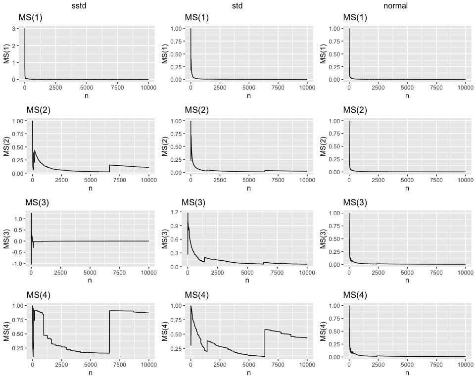

### MC

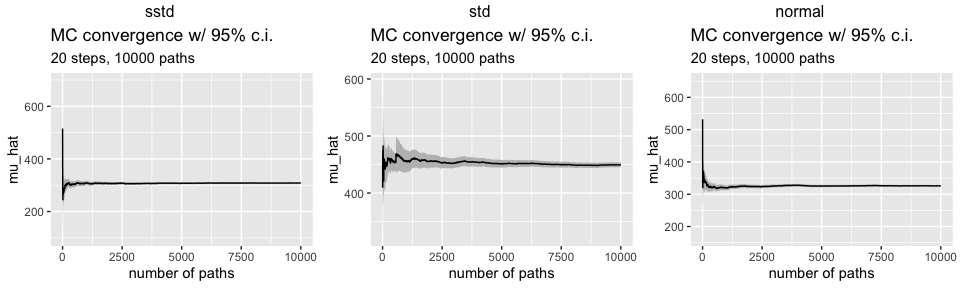

### IS

Skewed $t$-distribution with a normal proposal distribution.

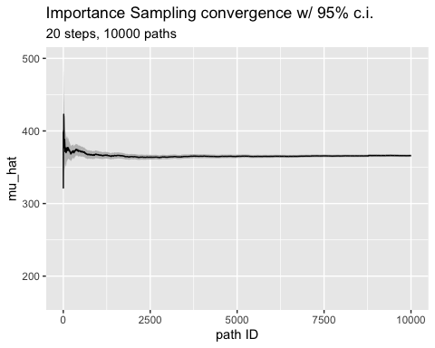

Parameters

```
## [1] 1.3814456 0.4037569
```

Objective function plots

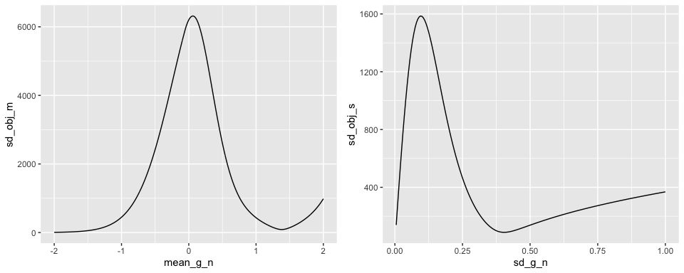

# Discussion

With the data frozen we can step back and ask what these numbers and graphs actually tell us.

## The plans are one portfolio at different leverage

The most consequential finding is structural. The four plans are not four different stock/bond mixes; they are weighted blends of the same two underlying funds (a low-risk and a high-risk building block), so the high-risk plan behaves like a *leveraged* version of the medium-risk plan. Empirically the high-risk series is a near-scalar multiple of the medium-risk series ($R^2$ of 0.91-0.98 with intercept $\approx 0$), and the first principal component explains about 96% of the joint variation across all four plans. Practically, the choice between risk profiles within a provider is a choice of **how much** of one portfolio to hold, not **which** portfolio – higher profiles buy a higher expected growth rate at the price of proportionally larger swings, with essentially no diversification difference between them.

## What “risk” looks like in the data

Because $\beta>1$ with near-zero intercept, the high-risk plan amplifies the common factor symmetrically. Over 2011-2023 that meant higher average returns (Velliv 8.5% vs 7.0%, PFA 9.5% vs 6.5%) but deeper drawdowns (worst year $-15.1\%$ vs $-13.2\%$ for Velliv, $-12.2\%$ vs $-9.6\%$ for PFA) and outright underperformance in flat or down years. The much-noted property that the cumulative high-risk path never dips below the medium-risk path is an artefact of starting the index in 2012 at a low point before a long bull market – not evidence that more risk is free. The monthly report develops this “path-crossing” point in detail (rebasing the index to a market peak makes the paths cross); the annual sample is too thin to add to it.

## What the data can and cannot tell us

This is the heart of the case study. The annual fits rest on **13 observations** for up to four parameters. The skewness parameter `xi` is driven to its boundary in every fit – a direct symptom that the shape simply is not identifiable from so few points. Taleb’s $\kappa$ / $n_{min}$ machinery (appendix) quantifies the gap: matching the convergence of 30 Gaussian observations would take far more than 30 observations from a Student-$t$ with $\nu\approx 3$. So for *point estimates of tail risk*, the honest answer is close to “stay home.”

## The mix and the fat-tail reading

The Monte-Carlo results are now produced as a single “black box” fit to each realised series rather than by combining independent simulations, which removes a spurious diversification effect that previously made the Velliv+PFA mixes look artificially safe. What remains – and what correlation alone misses – is a genuine *tail* benefit from mixing two fat-tailed providers: one provider’s idiosyncratic crash is softened because the mix always lies between the two. Quantifying that benefit against its cost is the subject of a separate analysis. On the distributional side, the fitted $\nu\approx 3$ implies (near-)infinite variance; the symmetric-$t$ Monte Carlo for the high-risk PFA profile diverges to absurd values, which is not a numerical error but the fit telling us its variance does not exist.

## Bottom line

For a fixed, crash-free, 13-point sample we can say a great deal *qualitatively* – the plans are leverage on one portfolio, the tails are fat, drawdowns are asymmetric, and apparent path-dominance is a starting-point artefact – while being honest that *quantitative* tail estimates are not trustworthy at this sample size. The next step is to turn the qualitative structure into the two decisions an investor actually faces: which risk level, and whether to split across providers.

# Appendix

## Infinite variance

Taleb, Statistical Consequences Of Fat Tails, p. 97:  
“the variance of a finite variance random variable with tail exponent $< 4$ will be infinite”.

And p. 363:  
“The hedging errors for an option portfolio (under a daily revision regime) over 3000 days, under a constant volatility Student T with tail exponent $\alpha = 3$. Technically the errors should not converge in finite time as their distribution has infinite variance.”

## QQ lines

Note: QQ lines by design pass through 1st and 3rd quantiles. They are not trendlines in the sense of linear regression.

## Arithmetic vs geometric mean

Let $m$ be the number of steps in each path and $n$ be the number of paths. $a$ is the initial capital. Use arithmetic mean for mean of all paths at time $t$:
$$\dfrac{a (e^{z_1} + e^{z_2} + \dots + e^{z_n})}{n}$$
where
$$z_i := x_{i, 1} + x_{i, 2} + \dots + x_{i, m}$$
Use geometric mean for mean of all steps in a single path $i$:
$$a e^{\frac{x_{i, 1} + x_{i, 2} + \dots + x_{i, m}}{m}} = a \sqrt[m]{e^{x_{i, 1} + x_{i, 2} + \dots + x_{i, m}}}$$

So for **Monte Carlo** of returns after $m$ periods, we

- fit a skewed t-distribution to log-returns and use that distribution to simulate $\{x_{i, j}\}_j^m$,
- for each path $i$, calculate $100\cdot e^{z_i}$,
- calculate the mean of $\{z_i\}_i^n$:
  - $$\bar{z} = 100\dfrac{e^{z_1} + e^{z_2} + \dots + e^{z_n}}{n}$$

For **Importance Sampling**, we

- model log-returns on a skewed t-distribution,
- for each path $i$, calculate $100\cdot e^{z_i}$,
- fit a skewed t-distribution to $\{z_i\}_i^n$ and use it as our $f$ density function from which we simulate $\{h_i\}_i^n$,
  - In our case $h$ and $z$ are identical, because we have an idea for a distribution to simulate $z$, but in general for IS $h$ could be a function of $z$.
- calculate $w* = \frac{f}{g^*}$, where $g*$ is our proposal distribution, which minimizes the variance of $h\cdot w$.
- calculate the arithmetic mean of $\{h_i w_i^{*}\}_i^n$:
  - $$100 \dfrac{e^{h_1 w_1^{*}} + e^{h_2 w_2^{*}} + \dots + e^{h_n w_n^{*}}}{n}$$

## Average of returns vs returns of average

### Math

$$\text{Avg. of returns} := \dfrac{ \left(\dfrac{x_t}{x_{t-1}} + \dfrac{y_t}{y_{t-1}} \right) }{2}$$
$$\text{Returns of avg.} := \left(\dfrac{ x_t + y_t }{2}\right) \Big/ \left(\dfrac{ x_{t-1} + y_{t-1} }{2}\right) \equiv \dfrac{ x_t + y_t }{ x_{t-1} + y_{t-1}}$$

For which $x_1$ and $y_1$ are $\text{Avg. of returns} = \text{Returns of avg.}$?

$$\dfrac{ \left(\dfrac{x_t}{x_{t-1}} + \dfrac{y_t}{y_{t-1}} \right) }{2} = \dfrac{ x_t + y_t }{ x_{t-1} + y_{t-1}}$$

$$\dfrac{x_t}{x_{t-1}} + \dfrac{y_t}{y_{t-1}} = 2 \dfrac{ x_t + y_t }{ x_{t-1} + y_{t-1}}$$

$$(x_{t-1} + y_{t-1}) x_t y_{t-1} + (x_{t-1} + y_{t-1}) x_{t-1} y_t = 2 (x_{t-1}y_{t-1}x_t + x_{t-1}y_{t-1}y_t)$$

$$(x_{t-1}x_ty_{t-1} + y_{t-1}x_ty_{t-1}) + (x_{t-1}x_{t-1}y_t + x_{t-1}y_{t-1}y_t) = 2(x_{t-1}y_{t-1}x_t + x_{t-1}y_{t-1}y_t)$$
This is not generally true, but true if for instance $x_{t-1} = y_{t-1}$.

### Example

Definition: `R = 1+r`

```
## Let x_0 be 100.
```

```
## Let y_0 be 200.
```

```
## So the initial value of the pf is 300 .
```

```
## Let R_x be 0.5.
```

```
## Let R_y be 1.5.
```

Then,

```
## x_1 is R_x * x_0 = 50.
```

```
## y_1 is R_y * y_0 = 300.
```

Average of returns:

```
## 0.5 * (R_x + R_y) = 1
```

So here the value of the pf at t=1 should be unchanged from t=0:

```
## (x_0 + y_0) * 0.5 * (R_x + R_y) = 300
```

But this is clearly not the case:

```
## 0.5 * (x_1 + y_1) = 0.5 * (R_x * x_0 + R_y * y_0) = 175
```

Therefore we should take returns of average, not average of returns!

Let’s take the average of log returns instead:

```
## 0.5 * (log(R_x) + log(R_y)) = -0.143841
```

We now get:

```
## (x_0 + y_0) * exp(0.5 * (log(Rx) + log(Ry))) = 259.8076
```

So taking the average of log returns doesn’t work either.

## Simulation of mix vs mix of simulations

Test if a simulation of a mix (average) of two returns series has the same distribution as a mix of two simulated returns series.

```
## m(data_x): -0.06102962
## s(data_x): 0.4340772
## m(data_y): 9.541337
## s(data_y): 2.380286
##
## m(data_x + data_y): 4.740154
## s(data_x + data_y): 1.194826
```

m and s of final state of all paths.  
`_a` is mix of simulated returns.  
`_b` is simulated mixed returns.

| m_a | m_b | s_a | s_b |
| --- | --- | --- | --- |
| 94.853 | 94.852 | 5.340 | 5.381 |
| 94.645 | 94.668 | 5.627 | 5.213 |
| 95.001 | 95.069 | 5.356 | 5.585 |
| 94.759 | 94.572 | 5.452 | 5.051 |
| 94.743 | 94.985 | 5.429 | 5.509 |
| 94.834 | 94.998 | 5.311 | 5.580 |
| 95.071 | 94.927 | 5.473 | 5.263 |
| 94.427 | 94.720 | 5.193 | 5.286 |
| 94.750 | 94.874 | 5.376 | 5.419 |
| 94.894 | 94.712 | 5.451 | 5.344 |

```
##       m_a             m_b             s_a             s_b
##  Min.   :94.43   Min.   :94.57   Min.   :5.193   Min.   :5.051
##  1st Qu.:94.74   1st Qu.:94.71   1st Qu.:5.344   1st Qu.:5.268
##  Median :94.80   Median :94.86   Median :5.402   Median :5.362
##  Mean   :94.80   Mean   :94.84   Mean   :5.401   Mean   :5.363
##  3rd Qu.:94.88   3rd Qu.:94.97   3rd Qu.:5.452   3rd Qu.:5.486
##  Max.   :95.07   Max.   :95.07   Max.   :5.627   Max.   :5.585
```

`_a` and `_b` are very close to equal.  
We attribute the differences to differences in estimating the distributions in version a and b.

The final state is independent of the order of the preceding steps:

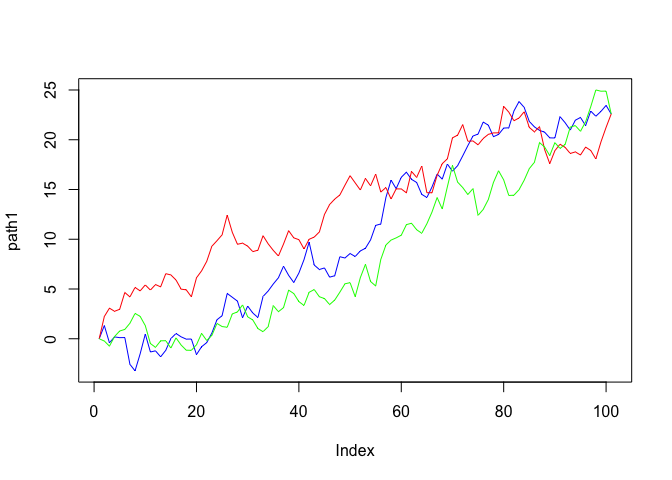

So does the order of the steps in the two processes matter, when mixing simulated returns?

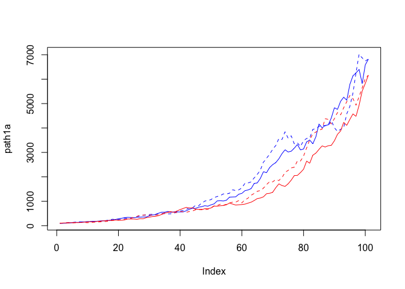

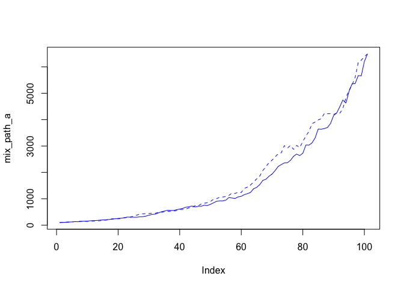

The order of steps in the individual paths do not matter, because the mix of simulated paths is a sum of a sum, so the order of terms doesn’t affect the sum. If there is variation it is because the sets preceding steps are not the same. For instance, the steps between step 1 and 60 in the plot above are not the same for the two lines.

Recall,
$$\text{Var}(aX+bY) = a^2 \text{Var}(X) + b^2 \text{Var}(Y) + 2ab \text{Cov}(a, b)$$

```r
var(0.5 * vhr + 0.5 * phr)
```

```
## [1] 0.01055146
```

```r
0.5^2 * var(vhr) + 0.5^2 * var(phr) + 2 * 0.5 * 0.5 * cov(vhr, phr)
```

```
## [1] 0.01055146
```

Our distribution estimate is based on 13 observations. Is that enough for a robust estimate? What if we suddenly hit a year like 2008? How would that affect our estimate?  
Let’s try to include the Velliv data from 2007-2010.  
We do this by sampling 13 observations from `vmrl`.

```
##        m                 s
##  Min.   :0.06037   Min.   :0.04111
##  1st Qu.:0.06623   1st Qu.:0.06221
##  Median :0.06848   Median :0.06818
##  Mean   :0.07002   Mean   :0.06877
##  3rd Qu.:0.07372   3rd Qu.:0.07326
##  Max.   :0.08551   Max.   :0.09233
```

## The meaning of `xi`

The fit for `mhr` has the highest `xi` value of all. This suggests right-skew:

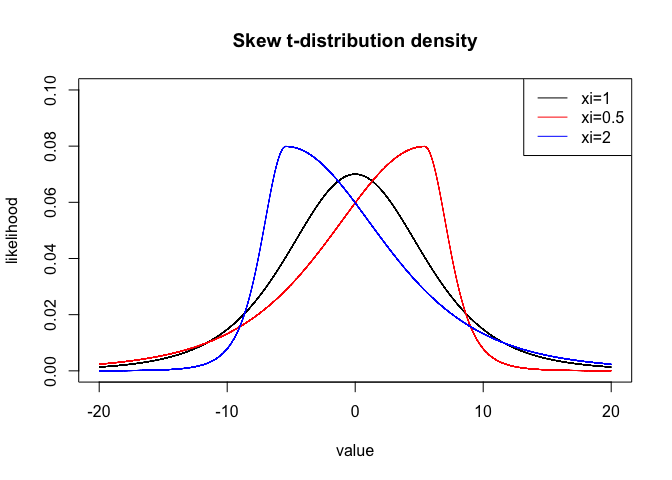

## Max vs sum plot

If the Law Of Large Numbers holds true,
$$\dfrac{\max (X_1^p, ..., X^p)}{\sum_{i=1}^n X_i^p} \rightarrow 0$$
for $n \rightarrow \infty$.

If not, $X$ doesn’t have a $p$’th moment.

See Taleb: The Statistical Consequences Of Fat Tails, p. 192